# Foundations for inference - Sampling distributions

Isaac Allen

Last compiled: Oct 14, 2020

This is a derivative of an [OpenIntro](https://www.openintro.org/stat/labs.php) lab, and is released under a [Attribution-NonCommercial-ShareAlike 3.0 United States](https://creativecommons.org/licenses/by-nc-sa/3.0/us/) license.

Complete all **Exercises and Questions**. Make sure you stage and commit all files to the GitHub Classroom.

## Getting Started

### Load packages

In this lab, you will explore the data using the `dplyr` package and visualize the data with the `ggplot2` package. The data can be found in the companion package for this course, `statsr`.

Start by loading the packages `statsr`, `dplyr`, and `ggplot2`.

```r
library(statsr)
library(dplyr)
library(ggplot2)
library(scales)
```

### The data

This lab uses real estate data from the city of Ames, Iowa. The details of every real estate transaction in Ames is recorded by the City Assessor’s office. The particular focus for this lab will be all residential home sales in Ames between 2006 and 2010. This collection represents the population of interest. In this lab, you will learn about these home sales by taking smaller samples from the full population. Start by loading the data.

```r
data(ames)
```

There are 82 variables in the `ames` data set. For this lab, you will only use two of the variables: the above ground living area of the house in square feet (`area`) and the sale price (`price`).

To explore the distribution of the homes’ `area`s in the population of home sales with a histogram consider Figure 1.

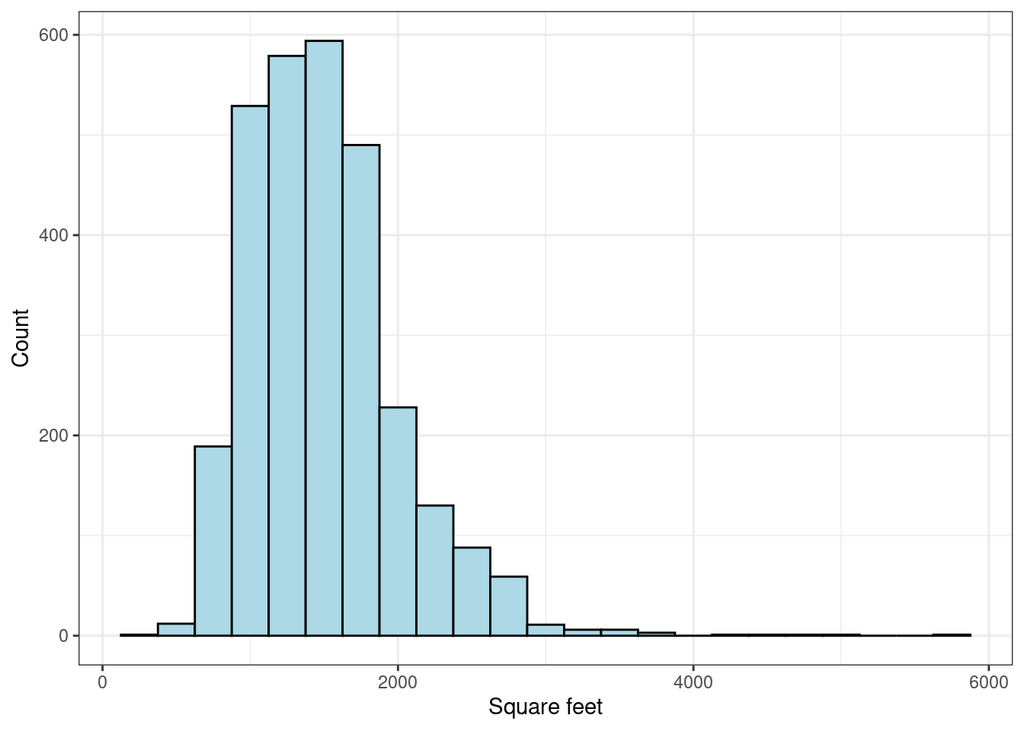

Figure 1: Histogram of `area` (square feet)

Summary statistics can be computed using the `summarize` function from `dplyr`. One can calculate as many statistics as needed using this function. Some of the functions below should be self explanatory (like `mean`, `median`, `sd`, `IQR`, `min`, and `max`). A new function here is the `quantile` function, which can be used to calculate values corresponding to specific percentile cutoffs in the distribution. For example `quantile(x, 0.25)` will yield the cutoff value for the 25<sup>th</sup> percentile (Q1) in the distribution of `x`. Finding appropriate values is useful for characterizing the distribution. The values are used for descriptions such as *“the middle 50% of the homes have areas between such and such square feet.”*

```r
POP <- ames %>%
  summarize(mu = mean(area), pop_med = median(area),
            sigma = sd(area)*sqrt((length(area) - 1)/length(area)), pop_iqr = IQR(area),
            pop_min = min(area), pop_max = max(area),
            pop_q1 = quantile(area, 0.25),  # first quartile, 25th percentile
            pop_q3 = quantile(area, 0.75))  # third quartile, 75th percentile
knitr::kable(POP, caption = "Population Parameters", col.names = c("$\\mu$", "$\\theta$", "$\\sigma$", "$IQR$", "$MIN$", "$MAX$", "$Q_1$", "$Q_3$"))
```

Table 1: Population Parameters

| $\mu$ | $\theta$ | $\sigma$ | $IQR$ | $MIN$ | $MAX$ | $Q_1$ | $Q_3$ |
| --- | --- | --- | --- | --- | --- | --- | --- |
| 1499.69 | 1442 | 505.4226 | 616.75 | 334 | 5642 | 1126 | 1742.75 |

1. Which of the following is **false**?
   1. The distribution of areas of houses in Ames is unimodal and right-skewed.
   2. 50% of houses in Ames are smaller than 1,499.69 square feet.
   3. The middle 50% of the houses range between approximately 1,126 square feet and 1,742.7 square feet.
   4. The IQR is approximately 616.7 square feet.
   5. The smallest house is 334 square feet and the largest is 5,642 square feet.

**B** is false. **55.26**% of houses in Ames are smaller than 1,499.69 square feet.

## The unknown sampling distribution

In this lab, the entire population is present, but this is rarely the case in real life. Gathering information on an entire population is often extremely costly or even impossible. Because of this, one will often take a sample of the population and use that sample to infer properties of the population.

If one were interested in estimating the mean living area in Ames based on a sample, one could use the following command to take a simple random sample (sampling without replacement) of size $n = 50$ from the population.

```r
samp1 <- ames %>%
  sample_n(size = 50)
```

This command creates a simple random sample of `size` 50 from the `ames` data-set and assigns the sample to `samp1`. This emulates going into the City Assessor’s database and pulling up the files on 50 random home sales. Working with these 50 files would be considerably simpler than working with all 2930 home sales.

**Exercise 1:** Describe the distribution of this sample? How does it compare to the distribution of the population? **Hint:** `sample_n` function takes a random sample of observations (i.e. rows) from the data-set, you can still refer to the variables in the data-set with the same names. Code you used in the previous exercise will also be helpful for visualizing and summarizing the sample; however, be careful not to label values `mu` and `sigma` anymore since these are sample statistics, not population parameters. You can customize the labels of any of the statistics to indicate that these come from the sample.

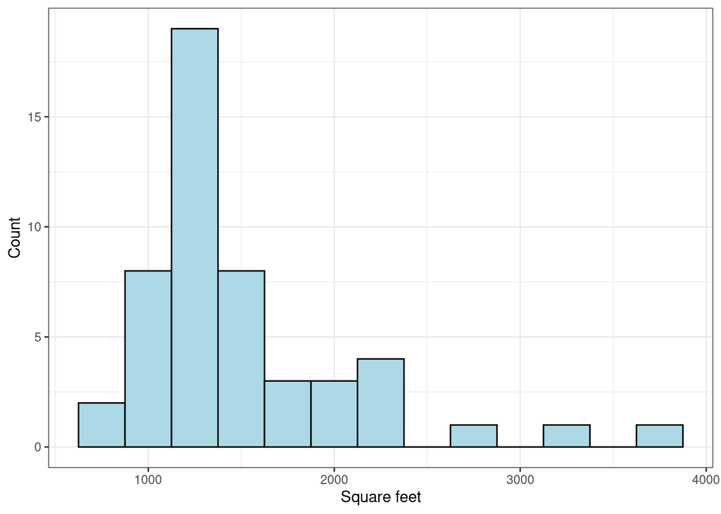

Figure 2: Histogram of the `area` (square feet) of a random sampling distribution from `ames`

```r
ex1 <- samp1 %>%
  summarize(xbar = mean(area), smp_med = median(area),
            sx = sd(area)*sqrt((length(area) - 1)/length(area)), smp_iqr = IQR(area),
            smp_min = min(area), smp_max = max(area),
            smp_q1 = quantile(area, 0.25),  # first quartile, 25th percentile
            smp_q3 = quantile(area, 0.75))  # third quartile, 75th percentile

knitr::kable(ex1, caption = "Sample Statistics", col.names = c("$\\bar{x}$", "$\\theta$", "$s$", "$IQR$", "$MIN$", "$MAX$", "$Q_1$", "$Q_3$"))
```

Table 2: Sample Statistics

| $\bar{x}$ | $\theta$ | $s$ | $IQR$ | $MIN$ | $MAX$ | $Q_1$ | $Q_3$ |
| --- | --- | --- | --- | --- | --- | --- | --- |
| 1514.7 | 1314 | 585.2807 | 473.5 | 844 | 3820 | 1186 | 1659.5 |

Overall, the results from this distribution of 50 samples coincides with that of the population distribution’s. Though results will vary due to set.seed() not being used, this sample’s $\bar{x}$, $\theta$, $s$, $IQR$, $MIN$, $MAX$, $Q_1$, and $Q_3$ deviates 15.01, -128, 79.86, -143.25, 510, -1822, 60, and -83.25 units of square feet from the population’s $\\mu$, $\theta$, $\sigma$, $IQR$, $MIN$, $MAX$, $Q_1$, and $Q_3$ respectively.

**If** one were interested in estimating the average living area in homes in Ames using the sample, the best single guess is the sample mean.

```r
samp1 %>%
  summarize(xbar = mean(area))
```

```
# A tibble: 1 x 1
   xbar
  <dbl>
1 1515.
```

Depending on which 50 homes one selects, their estimate could be above or below the true population mean of 1,499.69 square feet. However, the sample mean is the best unbiased estimate of the population mean (average living area), and we were able to get it by sampling less than 3% of the population.

2. Suppose we took two more samples, one of size 100 and one of size 1000. Which would you think would provide a more accurate estimate of the population mean?
   1. Sample size of 50.
   2. Sample size of 100.
   3. Sample size of 1000.

**C**, a sample size of 1000. The higher the amount of samples pulled from the population distribution, the higher the likelihood of it providing a more synonymous estimate.

Take one more sample of size 50, and compute the mean `area` of this sample:

```r
ames %>%
  sample_n(size = 50) %>%
  summarize(x_bar = mean(area))
```

```
# A tibble: 1 x 1
  x_bar
  <dbl>
1 1532.
```

Not surprisingly, every time a new random sample is generated, the resulting sample mean is generally different. It is useful to develop a sense of just how much variability one should expect when estimating the population mean this way. The distribution of sample means, called the *sampling distribution*, can help one understand this variability. In this lab, because you have access to the population, you can build up the sampling distribution for the sample mean by repeating the above steps many times. Consider the following code where the mean of 15,000 samples each of size $n = 50$ is computed. Note that the sampling for the sampling distribution is done with replacement.

```r
sample_means50 <- ames %>%
                    rep_sample_n(size = 50, reps = 15000, replace = TRUE) %>%
                    summarize(x_bar = mean(area))
```

In the previous code, `R` generates 15,000 samples each of size 50 from the population, computes the mean of each sample of size 50, and stores the result in a vector called `sample_means50`.

**Exercise 2**: How many elements are there in `sample_means50`? Describe the sampling distribution, and be sure to note its center. Make sure to include a plot of the distribution in your answer.

```r
ex2_1 <- tally(sample_means50)
ex2_2 <- sample_means50 %>% summarise(smp_med = median(x_bar))
```

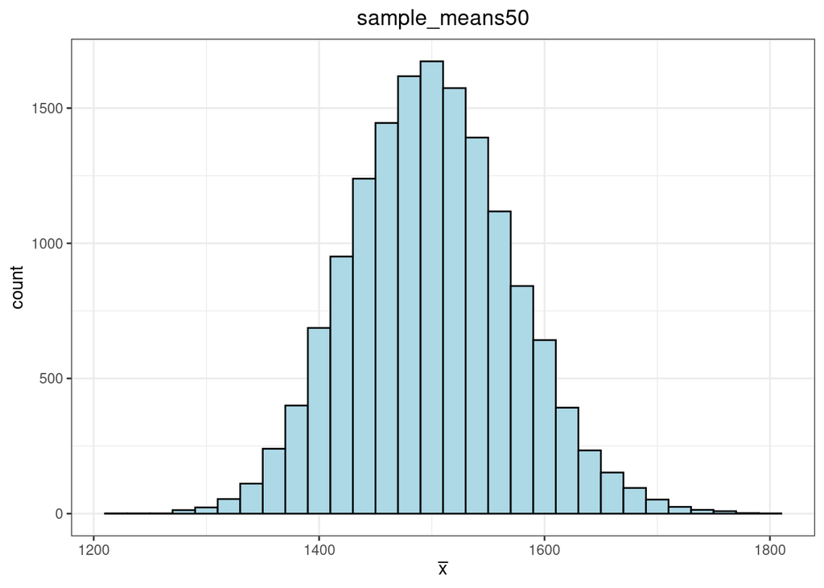

Figure 3: Sampling distribution of the sample mean ($\bar{x}$)

```r
ggplot(data = sample_means50, aes(x = x_bar)) +
  geom_histogram(binwidth = 20, fill = "lightblue", color = "black") +
  theme_bw() +
  labs(x = expression(bar(x))) +
  ggtitle("sample_means50") +
  theme(plot.title = element_text(hjust = 0.5))
```

There are 15000 elements in the `sample_means50` distribution. Because the center of `sample_means50` of 1498.65 is negligibly close to the population’s mean of 1499.69 (-1.04), it represents the population distribution with near precision. The histogram of `sample_means50` resembles a normal distribution.

## Interlude: Sampling distributions

The idea behind the `rep_sample_n` function is *repetition*. Earlier, a single sample of size $n = 50$ was taken from the population of all houses in Ames. With this new function, one is able to repeat this sampling procedure `rep` times in order to build a distribution of a series of sample statistics, called the **simulated sampling distribution**. The set of all possible values of the statistic and the frequency with which those values occur is the theoretical sampling distribution.

Note that in practice, one rarely gets to build theoretical sampling distributions because we rarely have access to data from the entire population.

Without the `rep_sample_n` function, this would be tedious. The following code would have to be run 15,000 times manually.

```r
ames %>%
  sample_n(size = 50) %>%
  summarize(x_bar = mean(area))
```

The resulting sample means would be stored each time in a separate object.

Note that for each of the 15,000 times a mean was computed, it was done from a **different** sample!

**Exercise 3**: To make sure you understand how sampling distributions are built and exactly what the `rep_sample_n` function is doing, try modifying the code to create a sampling distribution of **25 sample means** from **samples of size 10**, and put them in a data frame named `sample_means_small`. Print the output. How many observations are there in this object called `sample_means_small`? What does each observation represent?

```r
sample_means_small <- ames %>%
                    rep_sample_n(size = 10, reps = 25, replace = TRUE) %>%
                    summarize(x_bar = mean(area))
sample_means_small
```

```
# A tibble: 25 x 2
   replicate x_bar
       <int> <dbl>
 1         1 1647.
 2         2 1500.
 3         3 1783.
 4         4 1286.
 5         5 1506.
 6         6 1535.
 7         7 1677.
 8         8 1355.
 9         9 1508.
10        10 1797
# … with 15 more rows
```

There are 25 observations in the `sample_means_small` object. Each observation therein represents a sample mean of area generated via 25 separate samples of size 10.

3. How many elements are there in this object called `sample_means_small`?
   1. 0
   2. 3
   3. 25
   4. 100
   5. 5,000

```r
q3 <- tally(sample_means_small)
```

**C**, 25 elements.

4. Which of the following is **true** about the elements in the sampling distributions you created?
   1. Each element represents a mean square footage from a simple random sample of 10 houses.
   2. Each element represents the square footage of a house.
   3. Each element represents the true population mean of square footage of houses.

**A**, Each element represents a mean square footage from a simple random sample of 10 houses.

## Sample size and the sampling distribution

Mechanics aside, consider the reason one used the `rep_sample_n` function: to compute a sampling distribution, specifically, the one shown in Figure 4.

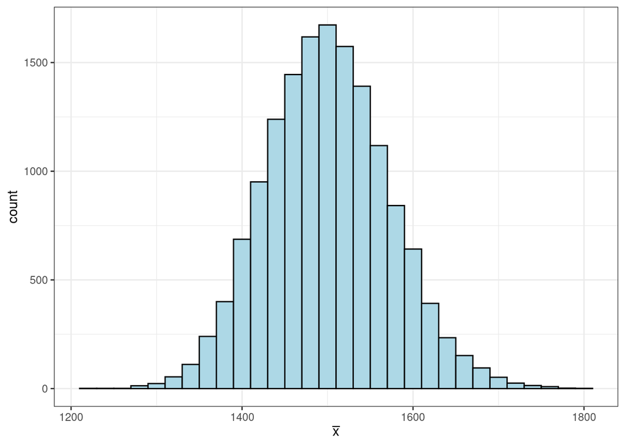

Figure 4: Sampling distribution of the sample mean ($\bar{x}$)

```r
ggplot(data = sample_means50, aes(x = x_bar)) +
  geom_histogram(binwidth = 20, fill = "lightblue", color = "black") +
  theme_bw() +
  labs(x = expression(bar(x)))
```

The sampling distribution computed in Figure 4 informs the reader about the average living area in homes in Ames. Because the sample mean is an unbiased estimator, the theoretical sampling distribution is centered at the true average living area of the population, and the theoretical spread of the distribution indicates how much variability is induced by sampling only 50 home sales.

In the remainder of this section, exercises are presented to show the reader the effect sample size has on the resulting sampling distributions.

**Exercise 4**: Use the app below to create sampling distributions of means of `area`s from samples of size 10, 30, 50, 100, and 500. Use 10,000 simulations. What does each observation in the sampling distribution represent? How does the mean, standard error, and shape of the sampling distribution change as the sample size increases? How (if at all) do these values change if you increase the number of simulations?

[interactive chart not shown]

5. It makes intuitive sense that as the sample size increases, the center of the sampling distribution becomes a more reliable estimate for the true population mean. As the sample size increases, the variability of the sampling distribution __________.
   1. decreases
   2. increases
   3. stays the same

**A**, Decreases.

**Exercise 5**: Take a random sample of size 50 from `price`. Using this sample, what is your best point estimate of the population mean?

```r
ex5 <- ames %>%
  sample_n(size = 50) %>%
  summarize(x_bar = mean(price))
```

My best point estimate of the population’s price mean given this single random sample of size 50 is $176,967.

**Exercise 6**: Since you have access to the population, simulate the sampling distribution for $\bar{x}_{price}$ by taking 5000 samples of size 50 from the population and computing 5000 sample means. Store these means in a vector called `sample_means50`. Plot the data; then, describe the shape of this sampling distribution. Based on this sampling distribution, what would you guess the mean home price of the population to be?

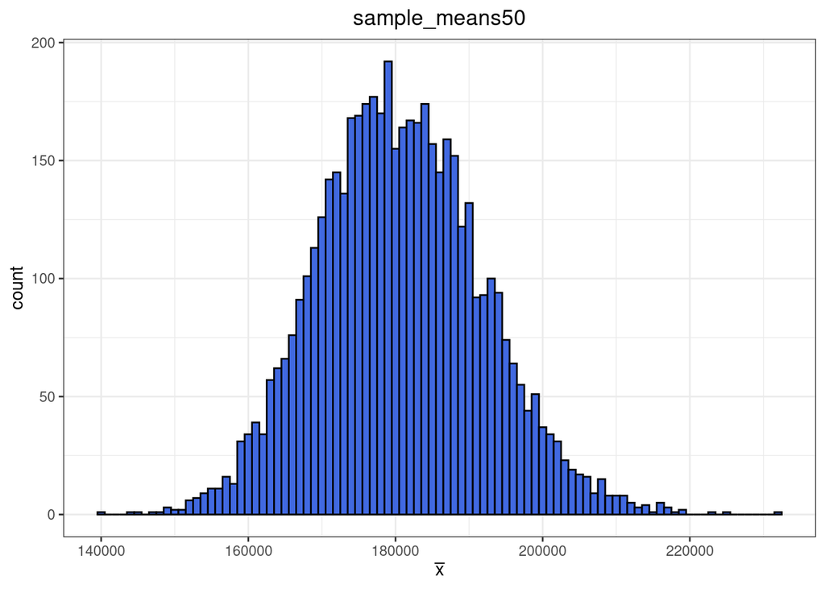

```r
sample_means50 <- ames %>%
                    rep_sample_n(size = 50, reps = 5000, replace = TRUE) %>%
                    summarize(x_bar = mean(price))

ggplot(data = sample_means50, aes(x = x_bar)) +
  geom_histogram(binwidth = 1000, fill = "royalblue", color = "black") +
  theme_bw() +
  labs(x = expression(bar(x))) +
  ggtitle("sample_means50") +
  theme(plot.title = element_text(hjust = 0.5))
```

The spread of this plot looks predominately even, fitting well into the bell shape of a normalized distribution. According to this sampling distribution, I would estimate the mean home price of the population to be $180,184.

**Exercise 7**: Change your sample size from 50 to 150. Then, compute a simulated sampling distribution using the same method as above, and store these means in a new vector called `sample_means150`. Describe the shape of this simulated sampling distribution, and compare it to the simulated sampling distribution for a sample size of 50. Based on this simulated sampling distribution, what would you estimate the mean sale price of homes in Ames is?

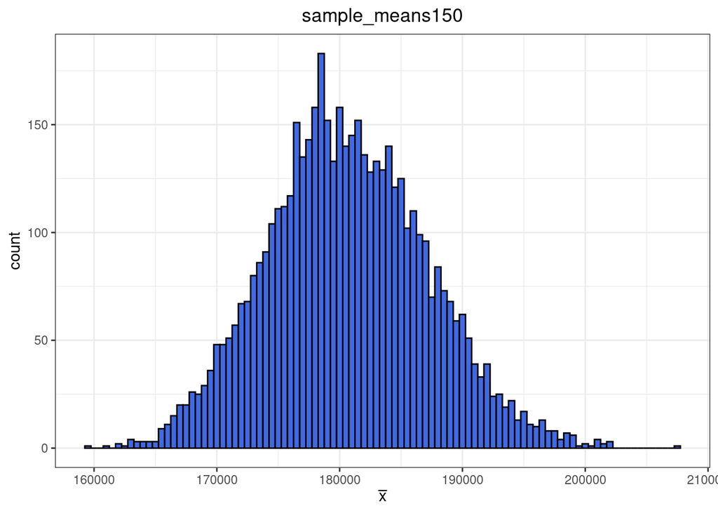

```r
sample_means150 <- ames %>%
                    rep_sample_n(size = 150, reps = 5000, replace = TRUE) %>%
                    summarize(x_bar = mean(price))

ggplot(data = sample_means150, aes(x = x_bar)) +
  geom_histogram(binwidth = 500, fill = "royalblue", color = "black") +
  theme_bw() +
  labs(x = expression(bar(x))) +
  ggtitle("sample_means150") +
  theme(plot.title = element_text(hjust = 0.5))
```

The spread of this plot looks even more bell shaped (i.e. normalized) than previous. According to this sampling distribution, I would estimate the mean home price of the population to be $180,385 (a difference of $201.49 from `sample_means50`’s and $3,418.47 from `ex5`’s).

So far, the focus has been on estimating the mean price for homes in Ames. Next, you will try to estimate the mean living area.

Note that while you might be able to answer some of these questions using the app, you are expected to write the required code and produce the necessary plots and summary statistics. You are welcomed to use the app for exploration.

**Exercise 8**: Take a sample of size 15 from the population and calculate the mean `area` of the homes in this sample. Using this sample, what is your best point estimate of the population mean area of homes?

```r
ex8 <- ames %>%
  sample_n(size = 15) %>%
  summarize(x_bar = mean(area))
```

My best point estimate of the population’s mean area of homes given this single random sample of size 15 is 1466 ft$^2$.

**Exercise 9**: Since you have access to the population, simulate the sampling distribution for $\bar{x}_{area}$ by taking 2000 samples from the population of size 15 and computing 2000 sample means. Store these means in a vector called `sample_means15`. Plot the data; then, describe the shape of this simulated sampling distribution. Based on this simulated sampling distribution, what would you estimate the mean home area of the population is? Finally, calculate and report the population mean.

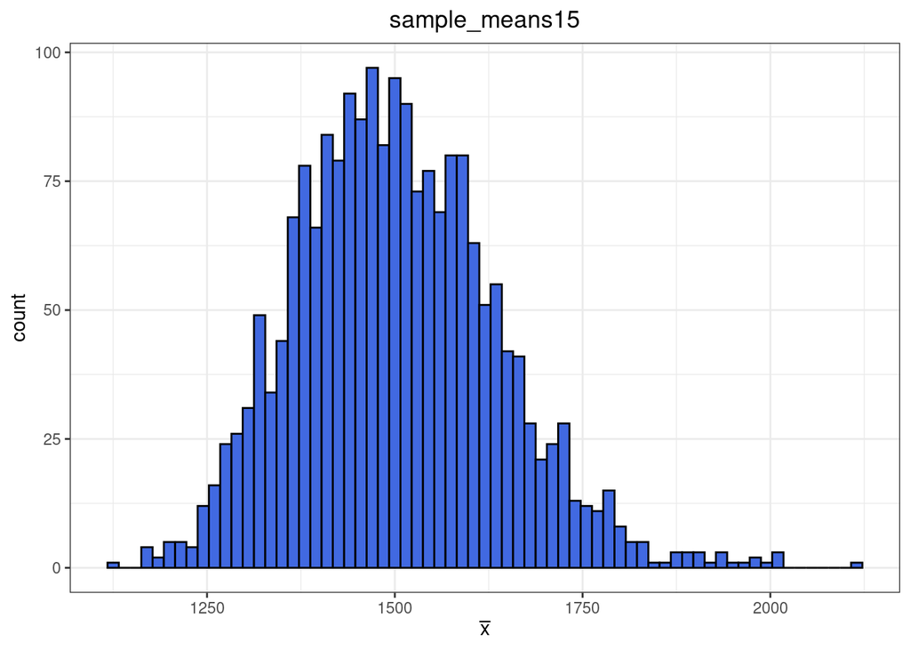

```r
sample_means15 <- ames %>%
                    rep_sample_n(size = 15, reps = 2000, replace = TRUE) %>%
                    summarize(x_bar = mean(area))

ggplot(data = sample_means15, aes(x = x_bar)) +
  geom_histogram(binwidth = 15, fill = "royalblue", color = "black") +
  theme_bw() +
  labs(x = expression(bar(x))) +
  ggtitle("sample_means15") +
  theme(plot.title = element_text(hjust = 0.5))
```

The spread of this plot looks predominately even, fitting well into the bell shape of a normalized distribution. According to this sampling distribution, I would estimate the home area of the population to be 1494.83ft$^2$.

**Exercise 10**: Change your sample size from 15 to 150. Then, compute the simulated sampling distribution using the same method as above, and store these means in a new vector called `sample_means150`. Describe the shape of this simulated sampling distribution, and compare it to the simulated sampling distribution for a sample size of 15. Based on this simulated sampling distribution, what would you estimate the mean area of homes in Ames is?

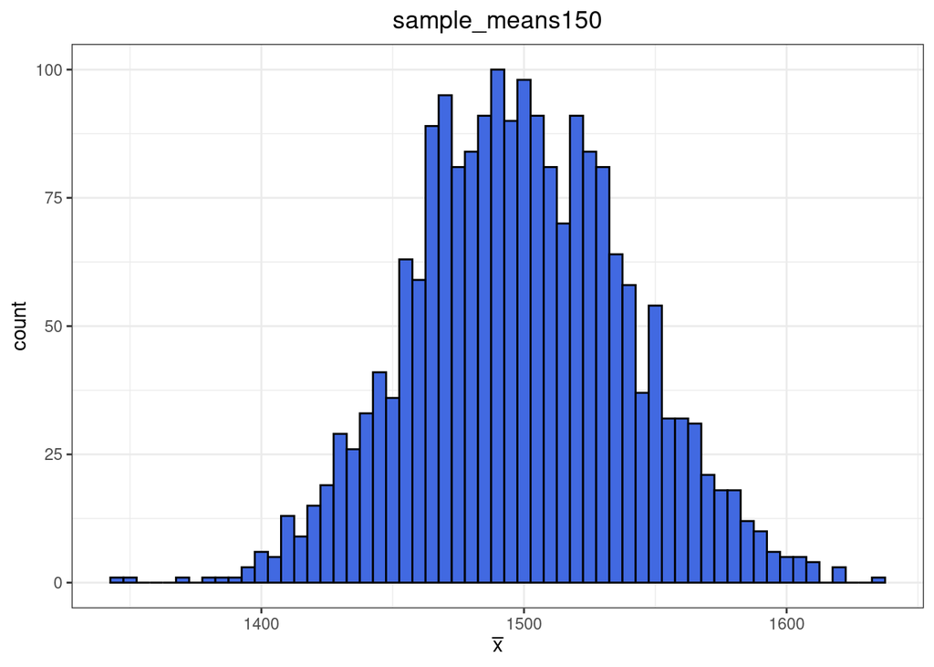

```r
sample_means150 <- ames %>%
                    rep_sample_n(size = 150, reps = 2000, replace = TRUE) %>%
                    summarize(x_bar = mean(area))

ggplot(data = sample_means150, aes(x = x_bar)) +
  geom_histogram(binwidth = 5, fill = "royalblue", color = "black") +
  theme_bw() +
  labs(x = expression(bar(x))) +
  ggtitle("sample_means150") +
  theme(plot.title = element_text(hjust = 0.5))
```

The spread of this plot looks even more bell shaped (i.e. normalized) than previous. According to this sampling distribution, I would estimate the home area of the population to be 1497.85ft$^2$ (a difference of 3ft$^2$ from `sample_means15`’s and 31.85ft$^2$ from `ex8`’s).

6. Which of the following is false?
   1. The variability of the simulated sampling distribution with the smaller sample size (`sample_means15`) is smaller than the variability of the simulated sampling distribution with the larger sample size (`sample_means150`).
   2. The means for the two sampling distributions are roughly similar.
   3. Both sampling distributions are symmetric.

```r
q6_means15 <- sample_means15 %>%
  summarize(sx = sd(x_bar)*sqrt((length(x_bar) - 1)/length(x_bar)))

q6_means150 <- sample_means150 %>%
  summarize(sx = sd(x_bar)*sqrt((length(x_bar) - 1)/length(x_bar)))

q6_means15$sx < q6_means150$sx
```

```
[1] FALSE
```

The variability of the simulated sampling distribution with the smaller sample size (sample_means15) is **larger** than the variability of the simulated sampling distribution with the larger sample size (sample_means150). Therefore **A** is false.